# Seventh Week: Generalized Linear Models

Murder or suicide

student name

2018-04-27 23:52:19

> با توجه به سوالات مرگ و میر در آمریکا به سوالات زیر پاسخ دهید.

۱. از میان متغیرهای داده مرگ و میر یک زیرمجموعه ایی بدون حشو در نظر بگیرید. ماتریس همبستگی متغیرهای مختلف را به دست آورده و سپس رسم نمایید. علاوه بر این نمودار پراکنش متغیرهای انتخاب شده را همزمان نسبت به هم رسم نمایید.

```r
library(readr)
library(dplyr)
```

```r
library(corrplot)
library(ggplot2)
library(knitr)
library(lmtest)
library(gridExtra)
library(Hmisc)
library(car)
library(h2o)
library(boot)
library(caret)
source("D:/University/Semester8/Data analysis/week7/hw_07/unbalanced_functions.R")
data = read.csv("D:/University/Semester8/Data analysis/week7/data/murder_suicide.csv")


data %>% select(ResidentStatus , Education2003Revision , Sex , MonthOfDeath , AgeRecode12,
                PlaceOfDeathAndDecedentsStatus,MaritalStatus,DayOfWeekOfDeath,InjuryAtWork,
                MannerOfDeath,MethodOfDisposition,PlaceOfInjury,NumberOfEntityAxisConditions,Race,BridgedRaceFlag,HispanicOrigin) ->data1

data$MannerOfDeath1 = data$MannerOfDeath - 2

q = data1

q[is.na(q)] <- "0"

n_q <- q[, sapply(q, is.numeric)]

kable(rcorr(as.matrix(n_q))$r)
```

|  | ResidentStatus | Education2003Revision | MonthOfDeath | AgeRecode12 | PlaceOfDeathAndDecedentsStatus | DayOfWeekOfDeath | MannerOfDeath | PlaceOfInjury | NumberOfEntityAxisConditions | Race | BridgedRaceFlag | HispanicOrigin |
| --- | --- | --- | --- | --- | --- | --- | --- | --- | --- | --- | --- | --- |
| ResidentStatus | 1.0000000 | 0.0125626 | 0.0007795 | -0.0925670 | 0.0330198 | 0.0023523 | 0.0737889 | 0.0781041 | -0.0097506 | 0.0156236 | -0.0056650 | 0.0580030 |
| Education2003Revision | 0.0125626 | 1.0000000 | 0.0209797 | 0.1834569 | 0.0372522 | -0.0036203 | -0.1593697 | -0.0398413 | 0.0241981 | 0.0089622 | 0.0051232 | 0.0527706 |
| MonthOfDeath | 0.0007795 | 0.0209797 | 1.0000000 | -0.0066647 | 0.0016659 | -0.0166120 | 0.0067005 | -0.0052775 | -0.0065582 | 0.0004803 | 0.0035407 | 0.0093560 |
| AgeRecode12 | -0.0925670 | 0.1834569 | -0.0066647 | 1.0000000 | 0.0006759 | -0.0026010 | -0.3000836 | -0.0974286 | 0.0576628 | -0.0455292 | -0.0574345 | -0.0562868 |
| PlaceOfDeathAndDecedentsStatus | 0.0330198 | 0.0372522 | 0.0016659 | 0.0006759 | 1.0000000 | 0.0030440 | -0.0615197 | 0.0319129 | -0.0567582 | -0.0007557 | -0.0066730 | -0.0001009 |
| DayOfWeekOfDeath | 0.0023523 | -0.0036203 | -0.0166120 | -0.0026010 | 0.0030440 | 1.0000000 | 0.0108975 | 0.0135030 | -0.0008785 | -0.0004159 | 0.0062888 | -0.0069196 |
| MannerOfDeath | 0.0737889 | -0.1593697 | 0.0067005 | -0.3000836 | -0.0615197 | 0.0108975 | 1.0000000 | 0.2431710 | -0.0244306 | 0.0210667 | 0.0093743 | 0.0746284 |
| PlaceOfInjury | 0.0781041 | -0.0398413 | -0.0052775 | -0.0974286 | 0.0319129 | 0.0135030 | 0.2431710 | 1.0000000 | 0.0012669 | 0.0062427 | 0.0106834 | 0.0272036 |
| NumberOfEntityAxisConditions | -0.0097506 | 0.0241981 | -0.0065582 | 0.0576628 | -0.0567582 | -0.0008785 | -0.0244306 | 0.0012669 | 1.0000000 | -0.0054186 | 0.0001789 | -0.0211167 |
| Race | 0.0156236 | 0.0089622 | 0.0004803 | -0.0455292 | -0.0007557 | -0.0004159 | 0.0210667 | 0.0062427 | -0.0054186 | 1.0000000 | 0.2185873 | -0.0208981 |
| BridgedRaceFlag | -0.0056650 | 0.0051232 | 0.0035407 | -0.0574345 | -0.0066730 | 0.0062888 | 0.0093743 | 0.0106834 | 0.0001789 | 0.2185873 | 1.0000000 | 0.0026088 |
| HispanicOrigin | 0.0580030 | 0.0527706 | 0.0093560 | -0.0562868 | -0.0001009 | -0.0069196 | 0.0746284 | 0.0272036 | -0.0211167 | -0.0208981 | 0.0026088 | 1.0000000 |

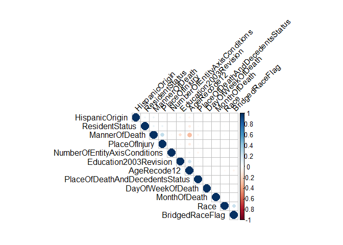

```r
corrplot(rcorr(as.matrix(n_q))$r, type = "upper", order = "hclust",tl.col = "black", tl.srt = 45)
```

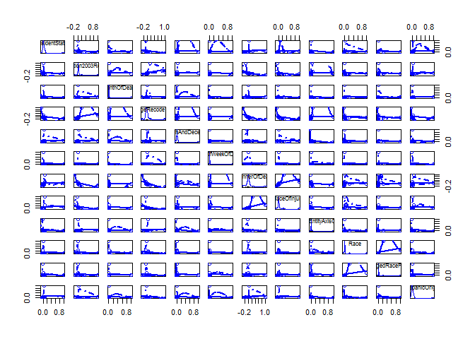

```r
scatterplotMatrix(cor(n_q))
```

۲. اثر هر یک از متغیرهای جنسیت، نژاد،آموزش، سن و نحوه تدفین را بر مرگ یا خودکشی ارزیابی کنید.

```r
s_c = NULL

d_c = NULL

for(i in 1:59979){

  if(data[i , 7] == "M"){

    s_c = c(s_c , 1)
  }

  else{

    s_c = c(s_c , 0)
  }

}

for(i in 1:59979){

  if(data[i , 21] == "B"){

    d_c = c(d_c , 1)
  }

  if(data[i , 21] == "C"){

    d_c = c(d_c , 2)
  }
  if(data[i , 21] == "D"){

    d_c = c(d_c , 3)
  }
  if(data[i , 21] == "E"){

    d_c = c(d_c , 4)
  }
  if(data[i , 21] == "O"){

    d_c = c(d_c , 5)
  }
  if(data[i , 21] == "R"){

    d_c = c(d_c , 6)

  }
  if(data[i , 21] == "U"){

    d_c = c(d_c , 7)
  }

}

data %>% mutate(Sex_c = s_c , Dis_c = d_c) ->data

data %>% select(Sex_c , MannerOfDeath) ->Sex_To_MannerOfDeath

chisq.test(as.matrix(Sex_To_MannerOfDeath))
```

```
##
##  Pearson's Chi-squared test
##
## data:  as.matrix(Sex_To_MannerOfDeath)
## X-squared = 13548, df = 59978, p-value = 1
```

```r
data %>% select(Race , MannerOfDeath) ->Race_To_MannerOfDeath

chisq.test(as.matrix(Race_To_MannerOfDeath))
```

```
##
##  Pearson's Chi-squared test
##
## data:  as.matrix(Race_To_MannerOfDeath)
## X-squared = 64149, df = 59978, p-value < 2.2e-16
```

```r
data %>% select(Education2003Revision , MannerOfDeath) ->Edu_To_MannerOfDeath

chisq.test(as.matrix(Edu_To_MannerOfDeath))
```

```
##
##  Pearson's Chi-squared test
##
## data:  as.matrix(Edu_To_MannerOfDeath)
## X-squared = 39600, df = 59978, p-value = 1
```

```r
data %>% select(AgeRecode12 , MannerOfDeath) ->Age_To_MannerOfDeath

chisq.test(as.matrix(Age_To_MannerOfDeath))
```

```
##
##  Pearson's Chi-squared test
##
## data:  as.matrix(Age_To_MannerOfDeath)
## X-squared = 17644, df = 59978, p-value = 1
```

```r
data %>% select(Dis_c , MannerOfDeath) ->Disposition_To_MannerOfDeath

chisq.test(as.matrix(Disposition_To_MannerOfDeath))
```

```
##
##  Pearson's Chi-squared test
##
## data:  as.matrix(Disposition_To_MannerOfDeath)
## X-squared = 30836, df = 59978, p-value = 1
```

۳. با استفاده از مدل رگرسیون لاجستیک یک مدل به داده ها برازش دهید و سپس آن را نقص یابی کنید.

```r
fit = glm(data = data , MannerOfDeath-2 ~ ResidentStatus + Education2003Revision + Sex + MonthOfDeath + AgeRecode12 + PlaceOfDeathAndDecedentsStatus + MaritalStatus + DayOfWeekOfDeath + InjuryAtWork + MethodOfDisposition + PlaceOfInjury + Race, family = "binomial")

print(fit)
```

```
##
## Call:  glm(formula = MannerOfDeath - 2 ~ ResidentStatus + Education2003Revision +
##     Sex + MonthOfDeath + AgeRecode12 + PlaceOfDeathAndDecedentsStatus +
##     MaritalStatus + DayOfWeekOfDeath + InjuryAtWork + MethodOfDisposition +
##     PlaceOfInjury + Race, family = "binomial", data = data)
##
## Coefficients:
##                    (Intercept)                  ResidentStatus
##                       1.390294                        0.150432
##          Education2003Revision                            SexM
##                      -0.224405                       -0.120797
##                   MonthOfDeath                     AgeRecode12
##                       0.006994                       -0.209237
## PlaceOfDeathAndDecedentsStatus                  MaritalStatusM
##                      -0.070712                       -0.195075
##                 MaritalStatusS                  MaritalStatusU
##                       0.553501                        1.280970
##                 MaritalStatusW                DayOfWeekOfDeath
##                       0.171479                        0.008554
##                  InjuryAtWorkU                   InjuryAtWorkY
##                      -0.298795                        1.340248
##           MethodOfDispositionC            MethodOfDispositionD
##                      -1.084525                       -1.573415
##           MethodOfDispositionE            MethodOfDispositionO
##                      -0.419746                        0.027004
##           MethodOfDispositionR            MethodOfDispositionU
##                      -0.275403                       -1.302504
##                  PlaceOfInjury                            Race
##                       0.040974                        0.002433
##
## Degrees of Freedom: 59978 Total (i.e. Null);  59957 Residual
## Null Deviance:       71220
## Residual Deviance: 57540     AIC: 57580
```

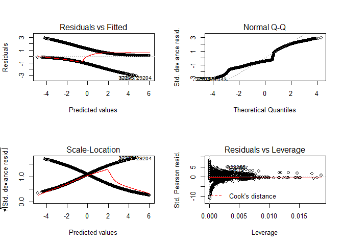

```r
par(mfrow=c(2,2))
plot(fit)
```

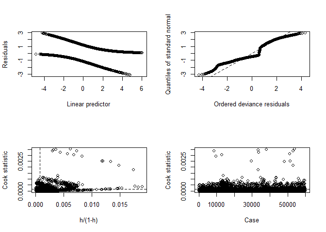

```r
glm.diag.plots(fit, glmdiag = glm.diag(fit))
```

۴. با استفاده از سه نمودار خروجی مدل را نسبت به داده واقعی ارزیابی کنید.

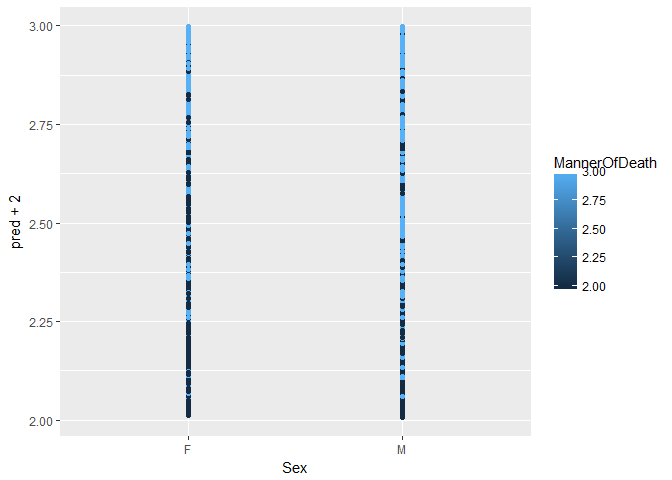

```r
a = data %>% mutate(pred = fitted(fit))
ggplot(data = a,aes(x = Sex,y = pred+2,col = MannerOfDeath))+geom_point()
```

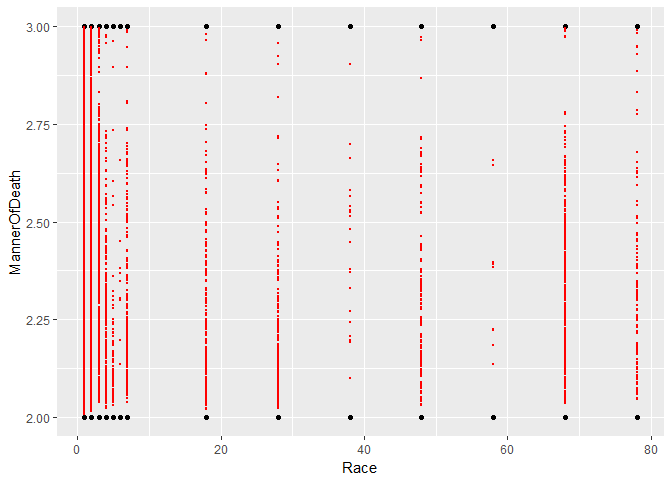

```r
ggplot(data = a, aes(x = Race, y = MannerOfDeath)) + geom_point() +
    geom_point(aes(x = Race, y = pred+2), color = 'red', size = 0.3)
```

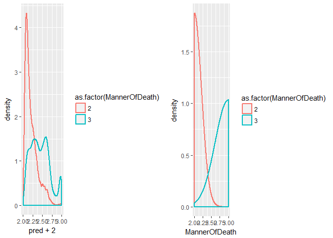

```r
ggplot( a, aes( pred+2, color = as.factor(MannerOfDeath))) +
    geom_density( size = 1 ) -> p1


ggplot( a, aes( MannerOfDeath, color = as.factor(MannerOfDeath))) +
    geom_density( size = 1 )->p2

grid.arrange(p1, p2, nrow = 1)
```

***

۵. ابتدا ۲۰ درصد داده را به صورت تصادفی به عنوان تست در نظر بگیرید. مدل را با استفاده از ۸۰ درصد باقی مانده برازش دهید. با استفاده از پارامتر قطع ۰.۵ نتایج را برای داده تست پیش بینی کنید. سپس کمیت های زیر را محاسبه کنید.

- P: positive samples
- N: negative samples
- TP: true positive TP (eqv. with hit)
- TN: true negative (eqv. with correct rejection)
- FP: false positive (eqv. with false alarm, Type I error)
- FN: false negative (eqv. with miss, Type II error)
- Accuracy (ACC) ACC = (TP+TN)/(P+T)
- False positive rate (FPR): 1- TN/N
- True positive rate (TPR): TP/P

مشابه آنچه در کلاس گفته شد نمایشی از چهار کمیت TN, TP,FP,FN به همراه داده ها رسم نمایید.

```r
index = sample(x= 1:nrow(data),size = 0.8*nrow(data),replace = F)

train = data[index,]
test =  data[-index,]

model_glm = glm(MannerOfDeath-2 ~ ResidentStatus + Education2003Revision + Sex + MonthOfDeath + AgeRecode12 + PlaceOfDeathAndDecedentsStatus + MaritalStatus + DayOfWeekOfDeath + InjuryAtWork + MethodOfDisposition + PlaceOfInjury + Race, data = train, family = "binomial")

test$prediction  = predict( model_glm, newdata = test , type = "response" )
train$prediction = predict( model_glm, newdata = train, type = "response" )

cm_info = ConfusionMatrixInfo( data = test, predict = "prediction", actual = "MannerOfDeath", cutoff = .5 )



h = table(cm_info$data$actual)

p = h[names(h) == 1]

n = h[names(h) == 0]

h1 = table(cm_info$data$type)

tp = h1[names(h1) == "TP"]

tn = h1[names(h1) == "TN"]

fp = h1[names(h1) == "FP"]

fn = h1[names(h1) == "FN"]

acc = (tp + tn)/(p + n)

fpr = fp / n

tpr = tp / p

paste("P = " , p)
```

```
## [1] "P =  3457"
```

```r
paste("N = " , n)
```

```
## [1] "N =  8539"
```

```r
paste("TP = " , tp)
```

```
## [1] "TP =  1374"
```

```r
paste("TN = " , tn)
```

```
## [1] "TN =  7795"
```

```r
paste("FP = " , fp)
```

```
## [1] "FP =  744"
```

```r
paste("FN = " , fn)
```

```
## [1] "FN =  2083"
```

```r
paste("ACC = " , acc)
```

```
## [1] "ACC =  0.764338112704235"
```

```r
paste("FPR = " , fpr)
```

```
## [1] "FPR =  0.0871296404731233"
```

```r
paste("TPR = " , tpr)
```

```
## [1] "TPR =  0.397454440266127"
```

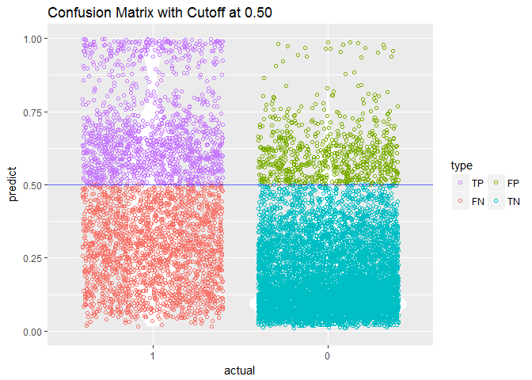

```r
cm_info$plot
```

۶. نمودار صحت مدل (accuracy) را بر حسب مقادیر مختلف قطع برای داده تست رسم نمایید. کدام پارامتر قطع بالاترین صحت را در پیش بینی داراست؟

مشاهده می شود cutoff = 0.45 بالا ترین صحت را در پیش بینی داراست.

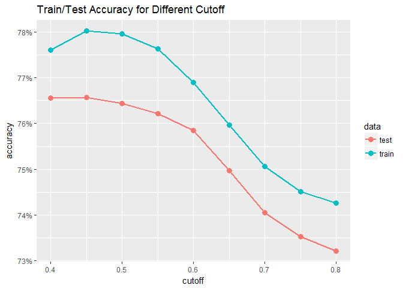

```r
accuracy_info = AccuracyCutoffInfo( train = train, test = test,predict = "prediction", actual = "MannerOfDeath" )

accuracy_info$plot
```

۷. نمودار ROC را برای داده های قسمت قبل رسم نمایید. همچنین نقطه مربوط به بهترین پارامتر قطع را مشخص نمایید.

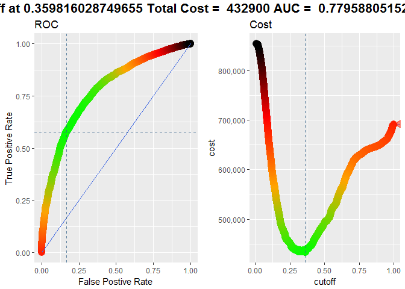

```r
cost_fp = 100;cost_fn = 200

roc_info = ROCInfo( data = cm_info$data, predict = "predict",
                     actual = "actual", cost.fp = cost_fp, cost.fn = cost_fn )

grid.draw(roc_info$plot)
```

```r
print(roc_info$cutoff)
```

```
## [1] 0.359816
```

۸. با قرار دادن کمیت nfolds = 5 و با استفاده از H20 مدل مساله را بسازید و نتیجه حاصل را ارزیابی کنید.

مشاهده می شود ضرایب دقت حدودا مشابه آنچه بالاتر به دست آوردیم است.

خطا بازه قابل قبولی دارد.

```r
h2o.init()
```

```
##  Connection successful!
##
## R is connected to the H2O cluster:
##     H2O cluster uptime:         1 hours 54 minutes
##     H2O cluster version:        3.16.0.2
##     H2O cluster version age:    4 months and 28 days !!!
##     H2O cluster name:           H2O_started_from_R_MOHAMMAD_AMIN_bto156
##     H2O cluster total nodes:    1
##     H2O cluster total memory:   0.06 GB
##     H2O cluster total cores:    8
##     H2O cluster allowed cores:  8
##     H2O cluster healthy:        TRUE
##     H2O Connection ip:          localhost
##     H2O Connection port:        54321
##     H2O Connection proxy:       NA
##     H2O Internal Security:      FALSE
##     H2O API Extensions:         Algos, AutoML, Core V3, Core V4
##     R Version:                  R version 3.4.1 (2017-06-30)
```

```r
happly = as.h2o(data)
chglm = h2o.glm(y = "MannerOfDeath1", x= c("ResidentStatus" , "Education2003Revision" , "Sex" , "MonthOfDeath" , "AgeRecode12",
                                  "PlaceOfDeathAndDecedentsStatus","MaritalStatus","DayOfWeekOfDeath","InjuryAtWork","MethodOfDisposition","PlaceOfInjury","Race"),
                training_frame = happly, family="binomial",nfolds = 5)
print(chglm)
```

```
## Model Details:
## ==============
##
## H2OBinomialModel: glm
## Model ID:  GLM_model_R_1524850302525_39
## GLM Model: summary
##     family  link                                regularization
## 1 binomial logit Elastic Net (alpha = 0.5, lambda = 2.697E-4 )
##   number_of_predictors_total number_of_active_predictors
## 1                         25                          23
##   number_of_iterations training_frame
## 1                    4           data
##
## Coefficients: glm coefficients
##                   names coefficients standardized_coefficients
## 1             Intercept     1.368098                 -0.550443
## 2 MethodOfDisposition.B     0.431137                  0.431137
## 3 MethodOfDisposition.C    -0.647006                 -0.647006
## 4 MethodOfDisposition.D    -0.427320                 -0.427320
## 5 MethodOfDisposition.E     0.000000                  0.000000
##
## ---
##                             names coefficients standardized_coefficients
## 21                   MonthOfDeath     0.006729                  0.022800
## 22                    AgeRecode12    -0.211630                 -0.408139
## 23 PlaceOfDeathAndDecedentsStatus    -0.069648                 -0.136407
## 24               DayOfWeekOfDeath     0.008156                  0.016323
## 25                  PlaceOfInjury     0.040676                  0.612437
## 26                           Race     0.002358                  0.015559
##
## H2OBinomialMetrics: glm
## ** Reported on training data. **
##
## MSE:  0.1557259
## RMSE:  0.3946213
## LogLoss:  0.4798245
## Mean Per-Class Error:  0.2823716
## AUC:  0.7863444
## Gini:  0.5726888
## R^2:  0.2288351
```

[output cut: 72 more lines]

```
## ---
##                         mean           sd cv_1_valid cv_2_valid cv_3_valid
## precision          0.5444604 0.0060434155 0.53998023  0.5438773  0.5562146
## r2                0.22790416 0.0044358033 0.22259647 0.22977427 0.23462777
## recall             0.6467424 0.0034843185  0.6533294 0.64394164  0.6389218
## residual_deviance  11523.749     52.21898   11476.04  11514.935  11458.433
## rmse               0.3948553 0.0011482941 0.39696577 0.39320514 0.39334863
## specificity         0.788619  0.005797587  0.7808348  0.7920202 0.80051005
##                   cv_4_valid cv_5_valid
## precision          0.5507138  0.5315162
## r2                0.23382714 0.21869515
## recall              0.648099 0.64942014
## residual_deviance  11503.351  11665.988
## rmse              0.39411524  0.3966416
## specificity        0.7917344 0.77799565
```

۹. آیا ما میتوانیم سرویسی به قضات ارایه کنیم تا با استفاده از اطلاعات مرگ بتوانند موارد مشکوک به قتل را از خودکشی تفکیک دهند؟

ابتدا باید ذکر کنیم این مدل سازی ها نتیجه کاملا صحیح در بر ندارند و احتمال خطا همواره وجود دارد.

ولی می توان از چنین مدل سازی هایی استفاده کرد تا اگر تصمیمی گرفته خواهد شد با مدل سازی ها تطبیق داده شود و در موارد مشکوک تحقیقات بیشتری به عمل آید تا به نتیجه دلخواه برسیم.

(مثلا قاتل به قتل خود اعتراف کند!)